# DS 805 - Final Project

Author

Ashlyn Smith, Farzaneh Farhoodi, & Peyton Ramsey

# Source:

https://archive.ics.uci.edu/dataset/697/predict+students+dropout+and+academic+success

# Data dictionary

This dataset covers 4,424 students from a Portuguese higher education institution from several academic years. Each record includes the student’s background at enrollment like demographic info, financial situation, and macroeconomic conditions at the time. It also has first and second semester academic results. The target variable y is binary, Dropout (1) vs. Graduate or Enrolled (0), collapsed from the original three-class outcome.

**Key variables:**

- Target (y): Dropout (1) vs. Graduate/Enrolled (0), the outcome we are predicting
- Age.at.enrollment: Student’s age when they started school
- Curricular.units.1st.sem.approved: Courses passed in the first semester
- Curricular.units.2nd.sem.approved: Courses passed in the second semester
- Tuition.fees.up.to.date: Whether tuition is currently paid (1 = yes)
- Scholarship.holder: Whether the student holds a scholarship (1 = yes)
- Debtor: Whether the student carries debt with the institution (1 = yes)
- Gender: Student gender (1 = male, 0 = female)
- Marital.status: Encoded marital status category
- GDP: Gross domestic product at the time of enrollment
- Unemployment.rate: National unemployment rate at enrollment
- Inflation.rate: Inflation rate at enrollment

> Grades follow the Portuguese 0–20 scale; roughly, 10 is the minimum passing level (~2.0 US GPA), 14 reflects solid performance (~3.0), and 18–20 corresponds to excellence (~4.0).

> Admission grades are reported on a Portuguese 0–200 scale (essentially a 0–20 school grade ×10). For intuition, dividing by 10 and using 18–20 = ~A (4.0), 14–17 = ~B/C (3.0–2.0), and 10–13 = ~D (1.0) provides an approximate U.S. 4.0 GPA equivalent.

# Part One:

## Business goal and target definition:

**Business goal:** Can we predict which students enrolled in higher education are at risk of dropping out, so that academic advisors can intervene early with targeted support before it’s too late?

**Y definition:** The original dataset contains three outcome classes: Graduate, Enrolled, and Dropout. For this project, y is collapsed into a binary variable where Dropout = 1 (the negative/at-risk class) and Graduate or Enrolled = 0 (the positive class). This framing is justified because the actionable business concern is identifying students who will not complete their program , whether a student eventually graduates or is still progressing are both acceptable outcomes from an intervention standpoint

**Predict why it matters:** Student dropout represents a significant and costly consequence for both the university and the student because universities lose tuition revenue and funding tied to retention rates, while students lose time, money, and career momentum. Early prediction identification of at-risk students allows advisors, financial aid offices, and counseling services to target these students to help them maintain their schooling, such as academic coaching, emergency financial assistance, or course load adjustments. The cost of missing a true dropout (a false negative) is substantially higher than the cost of a false alarm because an unnecessary advising check-in wastes minimal resources, whereas a missed at-risk student may withdraw permanently. Because intervention opportunities narrow sharply after the first semester, a model that maximizes negative-class recall, catching as many true dropouts as possible, directly aligns with the university’s retention goals. This makes dropout prediction not just an academic exercise but a deployable tool for student success programs.

## Classification threshold

Because the cost of missing a true dropout is more costly than a false alarm, we will evaluate our models using both classification thresholds of 0.5 (the standard threshold) and 0.3 (a more aggresive threshold). This will allow us to fairly compare each model to achieve our goal of maximizing dropout detection. A threshold of 0.3 is used to increase recall by making the model more sensitive at the cost of increasing false positives, this fits our goal because we want to get the maximum true dropout prediction possible. In our case, missing a negative case (false negative) is very costly as it can have consequences for both the university and the student. The threshold of 0.5 is the default, but it can result in low recall when the positive class is imbalanced.

## Data quality checks

```r
library(caret)
library(dplyr)
library(kableExtra)
library(MASS)
library(class)
library(ggplot2)
library(tree)
library(randomForest)
library(e1071)
```

```r
df <- read.csv("C:/Users/ramse/msba-courses/ds 805/project/data.csv", sep = ";")

head(df)
```

```
  Marital.status Application.mode Application.order Course
1              1               17                 5    171
2              1               15                 1   9254
3              1                1                 5   9070
4              1               17                 2   9773
5              2               39                 1   8014
6              2               39                 1   9991
  Daytime.evening.attendance. Previous.qualification
1                           1                      1
2                           1                      1
3                           1                      1
4                           1                      1
5                           0                      1
6                           0                     19
  Previous.qualification..grade. Nacionality Mother.s.qualification
```

[output cut: 90 more lines]

```r
str(df)
```

```
'data.frame':   4424 obs. of  37 variables:
 $ Marital.status                                : int  1 1 1 1 2 2 1 1 1 1 ...
 $ Application.mode                              : int  17 15 1 17 39 39 1 18 1 1 ...
 $ Application.order                             : int  5 1 5 2 1 1 1 4 3 1 ...
 $ Course                                        : int  171 9254 9070 9773 8014 9991 9500 9254 9238 9238 ...
 $ Daytime.evening.attendance.                   : int  1 1 1 1 0 0 1 1 1 1 ...
 $ Previous.qualification                        : int  1 1 1 1 1 19 1 1 1 1 ...
 $ Previous.qualification..grade.                : num  122 160 122 122 100 ...
 $ Nacionality                                   : int  1 1 1 1 1 1 1 1 62 1 ...
 $ Mother.s.qualification                        : int  19 1 37 38 37 37 19 37 1 1 ...
 $ Father.s.qualification                        : int  12 3 37 37 38 37 38 37 1 19 ...
 $ Mother.s.occupation                           : int  5 3 9 5 9 9 7 9 9 4 ...
 $ Father.s.occupation                           : int  9 3 9 3 9 7 10 9 9 7 ...
 $ Admission.grade                               : num  127 142 125 120 142 ...
 $ Displaced                                     : int  1 1 1 1 0 0 1 1 0 1 ...
```

[output cut: 23 more lines]

**Missingness**

```r
# checking if there are missing values in dataset
n_rows <- nrow(df)
n_rows
```

```
[1] 4424
```

```r
n_complete <- sum(complete.cases(df))
n_complete
```

```
[1] 4424
```

**Convert all categorical predictors to factors**

```r
cat_vars <- c(
  "Marital.status",
  "Application.mode",
  "Application.order",
  "Course",
  "Daytime.evening.attendance.",
  "Previous.qualification",
  "Nacionality",
  "Mother.s.qualification",
  "Father.s.qualification",
  "Mother.s.occupation",
  "Father.s.occupation",
  "Displaced",
  "Educational.special.needs",
  "Debtor",
  "Tuition.fees.up.to.date",
  "Gender",
  "Scholarship.holder",
  "International"
)

df[cat_vars] <- lapply(df[cat_vars], as.factor)
```

## Exploratory analysis

```r
# create binary target: Dropout = 1, Graduate/Enrolled = 0
df$y <- ifelse(df$Target == "Dropout", 1, 0)
df$y <- factor(df$y, levels = c(0, 1), labels = c("Not Dropout", "Dropout"))
```

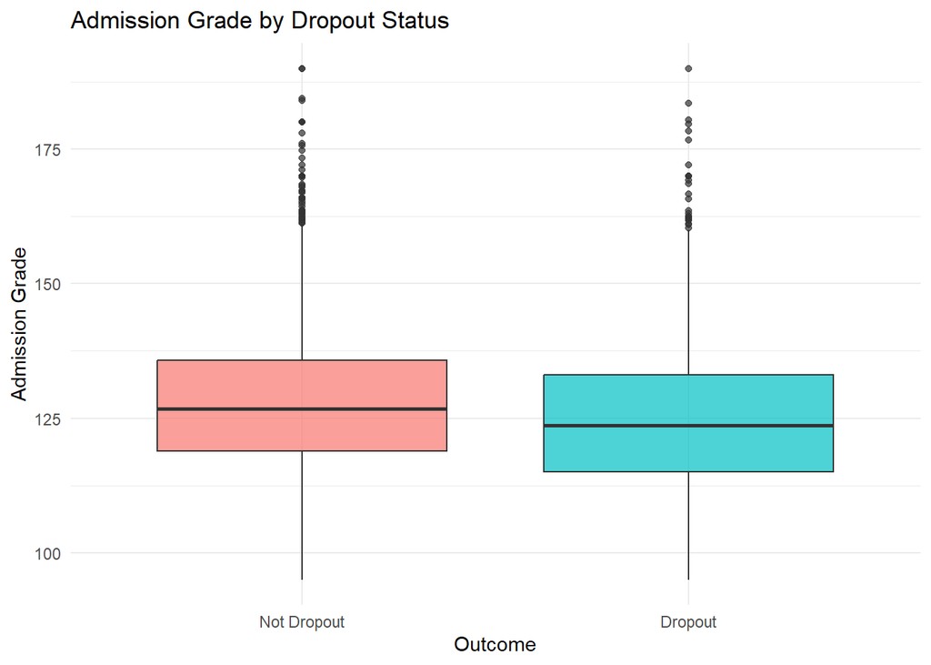

```r
# numeric plot 1: admission grade by dropout status
ggplot(df, aes(x = y, y = Admission.grade, fill = y)) +
  geom_boxplot(alpha = 0.7) +
  labs(title = "Admission Grade by Dropout Status",
       x = "Outcome", y = "Admission Grade") +
  theme_minimal() +
  theme(legend.position = "none")
```

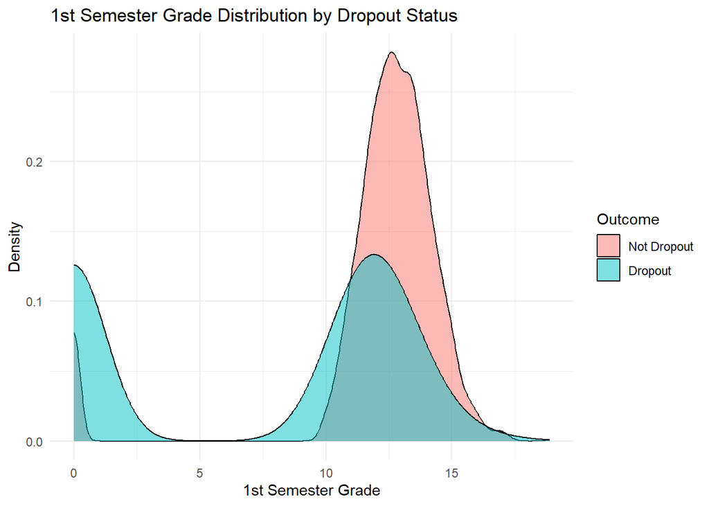

```r
# numeric plot 2: 1st semester grade by dropout status
ggplot(df, aes(x = Curricular.units.1st.sem..grade., fill = y)) +
  geom_density(alpha = 0.5) +
  labs(title = "1st Semester Grade Distribution by Dropout Status",
       x = "1st Semester Grade", y = "Density", fill = "Outcome") +
  theme_minimal()
```

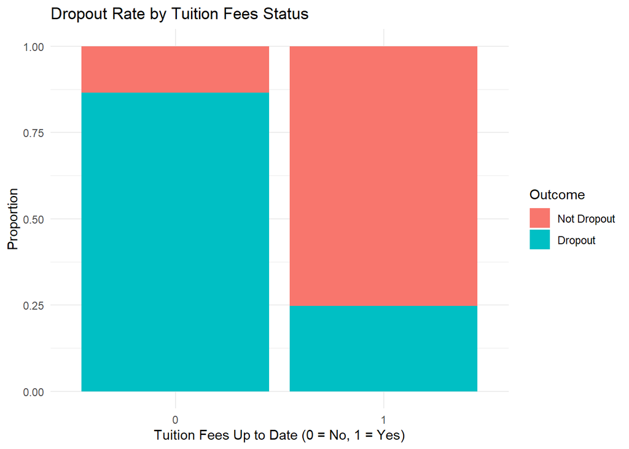

```r
# categorical plot 1: tuition fees up to date vs dropout
ggplot(df, aes(x = Tuition.fees.up.to.date, fill = y)) +
  geom_bar(position = "fill") +
  labs(title = "Dropout Rate by Tuition Fees Status",
       x = "Tuition Fees Up to Date (0 = No, 1 = Yes)",
       y = "Proportion", fill = "Outcome") +
  theme_minimal()
```

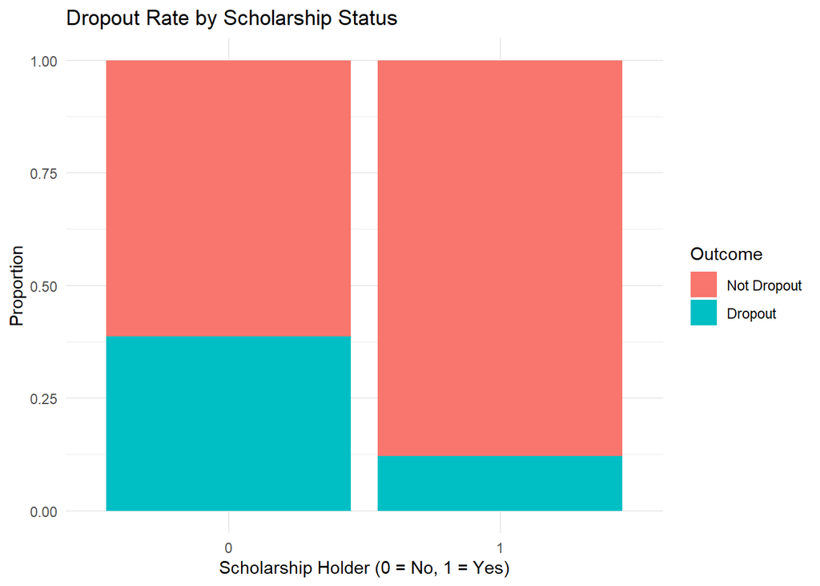

```r
# categorical plot 2: scholarship holder vs dropout
ggplot(df, aes(x = Scholarship.holder, fill = y)) +
  geom_bar(position = "fill") +
  labs(title = "Dropout Rate by Scholarship Status",
       x = "Scholarship Holder (0 = No, 1 = Yes)",
       y = "Proportion", fill = "Outcome") +
  theme_minimal()
```

## Train/test split

We should do a stratified sample because our ‘y’ is binary and likely imbalanced because there isn’t a 50/50 split for dropout students and non-drop out students. If we don’t apply stratification, our test set could under-represent the dropout class which makes our negative-class recall unreliable. Our goal of capturing dropouts requires a balanced set of dropouts and non-dropouts.

```r
# set a seed to train/test data
set.seed(31)
train_idx <- createDataPartition(df$y, p = 0.8, list = FALSE)
train <- df[train_idx, ]
test  <- df[-train_idx, ]

# training set rows
n_train <- nrow(train)
n_train
```

```
[1] 3540
```

```r
# testing set rows
n_test  <- nrow(test)
n_test
```

```
[1] 884
```

```r
# training set distribution
print(prop.table(table(train$y)))
```

```
Not Dropout     Dropout
  0.6788136   0.3211864
```

```r
# testing set distribution
print(prop.table(table(test$y)))
```

```
Not Dropout     Dropout
   0.678733    0.321267
```

# Part Two

```r
# Majority class classifier
majority_class <- names(which.max(table(train$y)))

baseline_pred <- factor(rep(majority_class, nrow(test)), levels = levels(test$y))

baseline_cm <- confusionMatrix(baseline_pred, test$y, positive = "Dropout")
baseline_cm
```

```
Confusion Matrix and Statistics

             Reference
Prediction    Not Dropout Dropout
  Not Dropout         600     284
  Dropout               0       0

               Accuracy : 0.6787
                 95% CI : (0.6468, 0.7094)
    No Information Rate : 0.6787
    P-Value [Acc > NIR] : 0.5161

                  Kappa : 0

 Mcnemar's Test P-Value : <2e-16

            Sensitivity : 0.0000
            Specificity : 1.0000
         Pos Pred Value :    NaN
         Neg Pred Value : 0.6787
             Prevalence : 0.3213
         Detection Rate : 0.0000
   Detection Prevalence : 0.0000
      Balanced Accuracy : 0.5000

       'Positive' Class : Dropout
```

```r
log_model <- glm(y ~ Tuition.fees.up.to.date + Curricular.units.1st.sem..grade. + Scholarship.holder + Debtor + Admission.grade, data = train, family = "binomial")

summary(log_model)
```

```
Call:
glm(formula = y ~ Tuition.fees.up.to.date + Curricular.units.1st.sem..grade. +
    Scholarship.holder + Debtor + Admission.grade, family = "binomial",
    data = train)

Coefficients:
                                  Estimate Std. Error z value Pr(>|z|)
(Intercept)                       5.136088   0.448715  11.446  < 2e-16 ***
Tuition.fees.up.to.date1         -2.588049   0.170112 -15.214  < 2e-16 ***
Curricular.units.1st.sem..grade. -0.196639   0.009571 -20.544  < 2e-16 ***
Scholarship.holder1              -1.185118   0.127125  -9.322  < 2e-16 ***
Debtor1                           0.489938   0.151035   3.244 0.001179 **
Admission.grade                  -0.011115   0.003104  -3.581 0.000342 ***
---
Signif. codes:  0 '***' 0.001 '**' 0.01 '*' 0.05 '.' 0.1 ' ' 1

(Dispersion parameter for binomial family taken to be 1)

    Null deviance: 4444.5  on 3539  degrees of freedom
Residual deviance: 3120.4  on 3534  degrees of freedom
AIC: 3132.4

Number of Fisher Scoring iterations: 5
```

```r
log_pred_prob <- predict(log_model, newdata = test, type = "response")

# threshold of 0.5
log_pred_050 <- ifelse(log_pred_prob > 0.5, "Dropout", "Not Dropout")
log_pred_050 <- factor(log_pred_050, levels = levels(test$y))
log_cm_050 <- confusionMatrix(log_pred_050, test$y, positive = "Dropout")
log_cm_050
```

```
Confusion Matrix and Statistics

             Reference
Prediction    Not Dropout Dropout
  Not Dropout         565     115
  Dropout              35     169

               Accuracy : 0.8303
                 95% CI : (0.8039, 0.8545)
    No Information Rate : 0.6787
    P-Value [Acc > NIR] : < 2.2e-16

                  Kappa : 0.5797

 Mcnemar's Test P-Value : 1.116e-10

            Sensitivity : 0.5951
            Specificity : 0.9417
         Pos Pred Value : 0.8284
         Neg Pred Value : 0.8309
             Prevalence : 0.3213
         Detection Rate : 0.1912
   Detection Prevalence : 0.2308
      Balanced Accuracy : 0.7684

       'Positive' Class : Dropout
```

```r
# threshold of 0.3
log_pred_030 <- ifelse(log_pred_prob > 0.3, "Dropout", "Not Dropout")
log_pred_030 <- factor(log_pred_030, levels = levels(test$y))
log_cm_030 <- confusionMatrix(log_pred_030, test$y, positive = "Dropout")
log_cm_030
```

```
Confusion Matrix and Statistics

             Reference
Prediction    Not Dropout Dropout
  Not Dropout         533      93
  Dropout              67     191

               Accuracy : 0.819
                 95% CI : (0.792, 0.8439)
    No Information Rate : 0.6787
    P-Value [Acc > NIR] : < 2e-16

                  Kappa : 0.5747

 Mcnemar's Test P-Value : 0.04811

            Sensitivity : 0.6725
            Specificity : 0.8883
         Pos Pred Value : 0.7403
         Neg Pred Value : 0.8514
             Prevalence : 0.3213
         Detection Rate : 0.2161
   Detection Prevalence : 0.2919
      Balanced Accuracy : 0.7804

       'Positive' Class : Dropout
```

```r
# test error rate
1 - log_cm_050$overall["Accuracy"]
```

```
 Accuracy
0.1696833
```

```r
1 - log_cm_030$overall["Accuracy"]
```

```
 Accuracy
0.1809955
```

```r
# negative-class recall
log_cm_050$byClass["Sensitivity"]
```

```
Sensitivity
  0.5950704
```

```r
log_cm_030$byClass["Sensitivity"]
```

```
Sensitivity
  0.6725352
```

**Which predictors we chose:** We chose five predictors based off of the EDA plots from above. Starting with Tuition.fees.up.to.date, it was chosen because it’s the strongest categorical predictor from the bar chart. Curricular.units.1st.sem..grade had the strongest numeric predictor from the density plot. Scholarship.holder had the second strongest categorical predictor. Debtor was chosen because it relates to the financial instability we saw in dropouts. Lastly, Admission.grade was chosen because to see if this is a strong predictor, although we didn’t see that visually in the boxplot.

**Interpretation:** All five of the predictors are statistically significant (p < 0.01) which backs-up our analyses made during the EDA. Logistic regression earned an Accuracy of 0.8303 and a test error rate of 16.97%, about half the Baseline model’s error rate of 32.13%. The negative-class recall rose from 0% to 59.51%, meaning that the logistic model was able to correctly predict about 6/10 true dropout students. We see that first-semester grades are a powerful predictor, each additional grade reduces the log-odds of dropping out by 0.197, showing that lower grades early on reflect academic disengagement. Although Debtor carries the weakest signal of the five predictors (p = 0.0012), it still adds information beyond tuition status, a student may be current on this semester’s fees but still carry debt from prior semesters, capturing a distinct dimension of financial distress. By lowering the threshold to 0.3, it increases negative-class recall from 59.51% to 67.25%, capturing ~7/10 true dropouts, however speicificity drops from 94.17% to 88.83% and test error rises from 16.97% to 18.1%. Given our goal of maximizing missed dropouts, the 0.3 threshold is the better choice for logistic regression as the gain in predicting tru dropouts is greater than the loss in true negatives.While the model performs well, it provides a conservative prediction on true dropouts with a specificity of 94.17% versus sensitivity of 59.51%. Because false negatives are cost-heavy, a lower classification threshold could be explored to improve dropout recall.

# Part 3

KNN measures distance between observations, so predictors on larger raw scales would dominate the distance calculation. Rather than scaling manually, we use caret’s `preProcess = c("center", "scale")` inside `train()`, which standardizes features correctly within each cross-validation fold (fitting the scaler on the training fold only, then applying it to the validation fold). This avoids data leakage that can occur when scaling the full dataset up front.

```r
# Subset to numeric predictors only, KNN cannot use factor columns
train_knn <- train %>%
  dplyr::select(where(is.numeric)) %>%
  mutate(y = train$y)

test_knn <- test %>%
  dplyr::select(where(is.numeric)) %>%
  mutate(y = test$y)

# k selection 10-fold repeated cross-validation, repeating 3 times
set.seed(31)
ctrl <- trainControl(method = "repeatedcv", number = 10, repeats = 3)

knnFit <- train(y ~ ., data = train_knn,  method = "knn", trControl = ctrl, preProcess = c("center", "scale"), tuneLength = 20)

knnFit
```

```
k-Nearest Neighbors

3540 samples
  18 predictor
   2 classes: 'Not Dropout', 'Dropout'

Pre-processing: centered (18), scaled (18)
Resampling: Cross-Validated (10 fold, repeated 3 times)
Summary of sample sizes: 3186, 3187, 3186, 3186, 3187, 3185, ...
Resampling results across tuning parameters:

  k   Accuracy   Kappa
   5  0.8117687  0.5403321
   7  0.8159108  0.5462645
   9  0.8202468  0.5533568
  11  0.8223168  0.5566231
  13  0.8231661  0.5564881
  15  0.8233547  0.5548486
  17  0.8216590  0.5486404
  19  0.8202468  0.5440910
  21  0.8219417  0.5467547
  23  0.8220362  0.5457303
  25  0.8209998  0.5415820
  27  0.8226017  0.5452172
  29  0.8219428  0.5433556
  31  0.8209081  0.5396135
  33  0.8210943  0.5392647
  35  0.8219415  0.5410598
  37  0.8211895  0.5385938
  39  0.8208126  0.5371687
  41  0.8191166  0.5318427
  43  0.8195887  0.5325578

Accuracy was used to select the optimal model using the largest value.
The final value used for the model was k = 15.
```

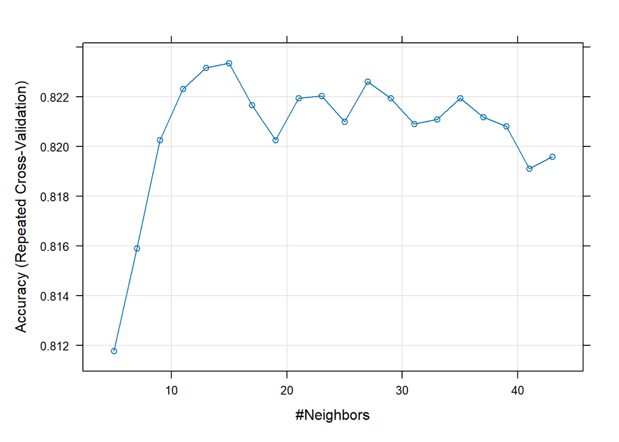

```r
plot(knnFit)
```

```r
# Best k chosen by caret
cat("Best k:", knnFit$bestTune$k, "\n")
```

```
Best k: 15
```

```r
# Get predicted probabilities
knn_pred_prob <- predict(knnFit, newdata = test_knn, type = "prob")[, "Dropout"]

# Threshold = 0.50 (explicit)
knn_pred_050 <- factor(ifelse(knn_pred_prob >= 0.50, "Dropout", "Not Dropout"), levels = levels(test_knn$y))
knn_cm_050 <- confusionMatrix(knn_pred_050, test_knn$y, positive = "Dropout")

# Threshold = 0.30
knn_pred_030 <- factor(ifelse(knn_pred_prob >= 0.30, "Dropout", "Not Dropout"), levels = levels(test_knn$y))
knn_cm_030 <- confusionMatrix(knn_pred_030, test_knn$y, positive = "Dropout")

# Compare
knn_threshold_comparison <- data.frame(
  Threshold = c("0.50", "0.30"),
  Error_Rate = c(round(1 - knn_cm_050$overall["Accuracy"], 4), round(1 - knn_cm_030$overall["Accuracy"], 4)),
  Neg_Class_Recall = c(round(knn_cm_050$byClass["Sensitivity"], 4), round(knn_cm_030$byClass["Sensitivity"], 4)),
  Specificity = c(round(knn_cm_050$byClass["Sensitivity"], 4), round(knn_cm_030$byClass["Sensitivity"], 4))
)
knn_threshold_comparison
```

```
  Threshold Error_Rate Neg_Class_Recall Specificity
1      0.50     0.1437           0.6197      0.6197
2      0.30     0.1821           0.7606      0.7606
```

**Interpretation:** Using 10-fold cross-validation, we found the optimal k to be 15, achieving a test error rate of 14.37% and a negative-class recall of 61.97% at the 0.5 threshold level, a minor improvement over logistic regression’s recall of 59.51%. This suggests the numeric feature space (grades, age, enrollment patterns) contains some non-linear structure that KNN can capture better than a linear decision boundary. By lowering the threshold to 0.3, it increases the negative-class recall from 61.97% to 76.06%, but specificity drops from 96.83% to 84.5%, and the test error rate rises from 14.37% to 18.21%. Our goal of minimizing missed true dropouts gives us the justification to accept the 0.3 threshold as the better choice for KNN, as the ~14% gain in negative-class recall offsets the cost of increase in false alarms. A key limitation is that KNN only accepts numeric predictors, meaning the categorical variables we identified as strong predictors in the EDA, tuition fee status and scholarship status, cannot be included, which likely holds back its recall performance. KNN also provides no coefficients or variable importance output, making it difficult to explain which features drive individual predictions to advisors or administrators.

# Part 4: Tree-based model

We chose Random Forest because it can capture non-linear interactions and uses all predictors, while maintaining good interpretability. Our goal is to predict which predictors matter most for predicting true dropouts. RF also handles categorical variables well, while subsampling at each split for each variables. We will tune two parameters, ‘mtry’ (features considered at each split) and `ntree` (number of trees).

**Finding and Tuning `mtry` & ‘ntree’**

```
mtry = 6  OOB error = 13.7%
Searching left ...
mtry = 4    OOB error = 13.33%
0.02680412 0.01
mtry = 3    OOB error = 13.45%
-0.008474576 0.01
Searching right ...
mtry = 9    OOB error = 14.12%
-0.05932203 0.01
```

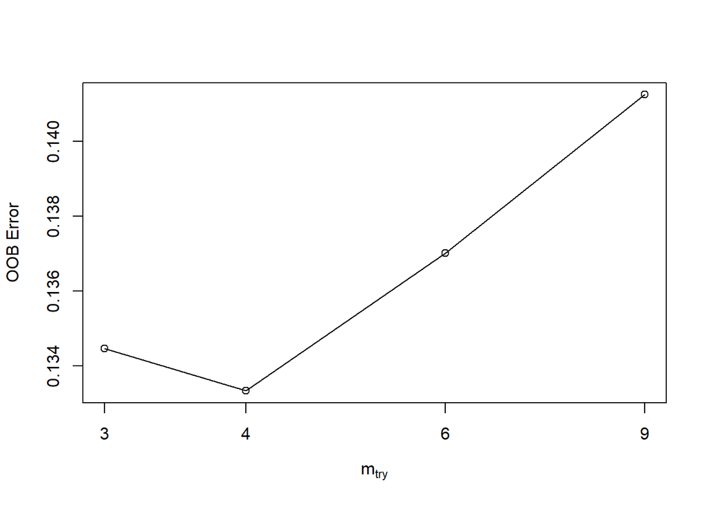

```r
# exclude original Target string column to avoid leakage
train_rf <- train[, !names(train) %in% "Target"]
test_rf <- test[, !names(test)  %in% "Target"]

# tune mtry parameter in RF model
set.seed(31)
tuneRF_result <- tuneRF(x = train_rf[, !names(train_rf) %in% "y"], y = train_rf$y, ntreeTry = 500, stepFactor = 1.5, improve = 0.01, trace = TRUE, plot = TRUE)
```

```r
# identify best mtry parameter value
best_mtry <- tuneRF_result[which.min(tuneRF_result[, 2]), 1]
cat("Best mtry:", best_mtry, "\n")
```

```
Best mtry: 4
```

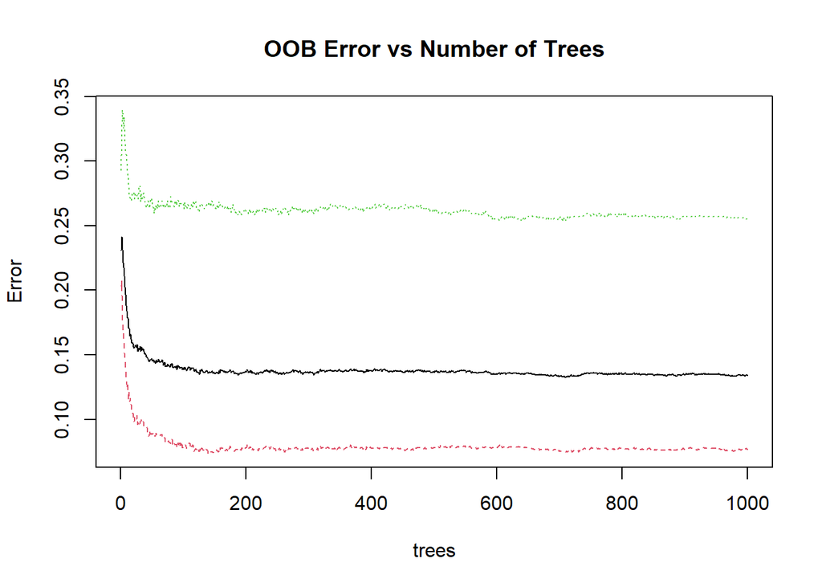

```r
# identifying best ntree parameter value, went back to line 301 to justify inputting 500
set.seed(31)
rf_ntree_check <- randomForest(y ~ ., data = train_rf, mtry = best_mtry, ntree = 1000)
plot(rf_ntree_check, main = "OOB Error vs Number of Trees")
```

**Fit final Random Forest**

```r
set.seed(31)
model_rf <- randomForest(y ~ ., data = train_rf, mtry = best_mtry, ntree = 500, importance = TRUE)

print(model_rf)
```

```
Call:
 randomForest(formula = y ~ ., data = train_rf, mtry = best_mtry,      ntree = 500, importance = TRUE)
               Type of random forest: classification
                     Number of trees: 500
No. of variables tried at each split: 4

        OOB estimate of  error rate: 13.28%
Confusion matrix:
            Not Dropout Dropout class.error
Not Dropout        2224     179  0.07449022
Dropout             291     846  0.25593668
```

**Evaluate on test set**

```r
pred_rf <- predict(model_rf, newdata = test_rf, type = "class")

cm_rf <- confusionMatrix(pred_rf, test_rf$y, positive = "Dropout")
cm_rf
```

```
Confusion Matrix and Statistics

             Reference
Prediction    Not Dropout Dropout
  Not Dropout         564      59
  Dropout              36     225

               Accuracy : 0.8925
                 95% CI : (0.8702, 0.9122)
    No Information Rate : 0.6787
    P-Value [Acc > NIR] : <2e-16

                  Kappa : 0.7482

 Mcnemar's Test P-Value : 0.024

            Sensitivity : 0.7923
            Specificity : 0.9400
         Pos Pred Value : 0.8621
         Neg Pred Value : 0.9053
             Prevalence : 0.3213
         Detection Rate : 0.2545
   Detection Prevalence : 0.2952
      Balanced Accuracy : 0.8661

       'Positive' Class : Dropout
```

```r
ter_rf <- round(1 - cm_rf$overall["Accuracy"], 4)
rf_recall <- round(cm_rf$byClass["Sensitivity"], 4)
cat("RF test error rate:", ter_rf, "\n")
```

```
RF test error rate: 0.1075
```

```r
cat("RF negative-class recall:", rf_recall, "\n")
```

```
RF negative-class recall: 0.7923
```

**Threshold comparison: 0.5 vs 0.3**

```r
# get predicted probabilities from RF
pred_rf_prob <- predict(model_rf, newdata = test_rf, type = "prob")[, "Dropout"]

# threshold = 0.50
pred_rf_050 <- factor(ifelse(pred_rf_prob >= 0.50, "Dropout", "Not Dropout"), levels = levels(test_rf$y))
cm_rf_050 <- confusionMatrix(pred_rf_050, test_rf$y, positive = "Dropout")

# threshold 0.30
pred_rf_030 <- factor(ifelse(pred_rf_prob >= 0.30, "Dropout", "Not Dropout"), levels = levels(test_rf$y))
cm_rf_030 <- confusionMatrix(pred_rf_030, test_rf$y, positive = "Dropout")

# compare side by side
threshold_comparison <- data.frame(
  Threshold = c("0.50", "0.30"),
  Error_Rate = c(round(1 - cm_rf_050$overall["Accuracy"], 4), round(1 - cm_rf_030$overall["Accuracy"], 4)),
  Neg_Class_Recall = c(round(cm_rf_050$byClass["Sensitivity"], 4), round(cm_rf_030$byClass["Sensitivity"], 4)),
  Specificity = c(round(cm_rf_050$byClass["Sensitivity"], 4), round(cm_rf_030$byClass["Sensitivity"], 4))
)
threshold_comparison
```

```
  Threshold Error_Rate Neg_Class_Recall Specificity
1      0.50     0.1075           0.7923      0.7923
2      0.30     0.1686           0.8979      0.8979
```

**Variable importance**

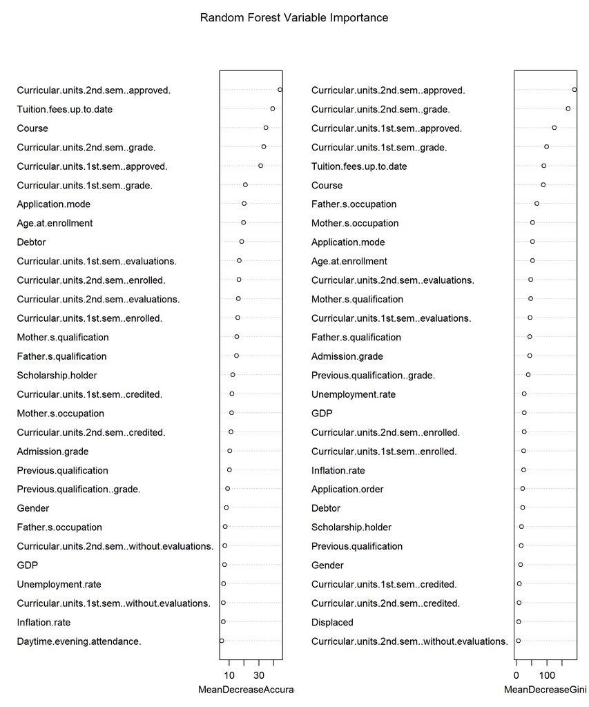

```r
varImpPlot(model_rf, main = "Random Forest Variable Importance")
```

# Part 5

```r
# exclude original Target column to avoid data leakage
train_svm <- train[, !names(train) %in% "Target"]
test_svm <- test[, !names(test)  %in% "Target"]

set.seed(31)

# tune over cost and gamma using 10-fold CV tune()
svm_tune <- tune(svm, y ~ ., data = train_svm, kernel = "radial",  ranges = list(cost = c(0.1, 1, 10), gamma = c(0.01, 0.1, 0.5)), probability = TRUE)

summary(svm_tune)
```

```
Parameter tuning of 'svm':

- sampling method: 10-fold cross validation

- best parameters:
 cost gamma
   10  0.01

- best performance: 0.1316384

- Detailed performance results:
  cost gamma     error dispersion
1  0.1  0.01 0.1855932 0.01658160
2  1.0  0.01 0.1361582 0.01247779
3 10.0  0.01 0.1316384 0.01593536
4  0.1  0.10 0.1932203 0.01326314
5  1.0  0.10 0.1401130 0.01484059
6 10.0  0.10 0.1460452 0.01351806
7  0.1  0.50 0.3211864 0.01845430
8  1.0  0.50 0.3214689 0.01805358
9 10.0  0.50 0.3206215 0.01944621
```

```r
svm_tune$best.parameters
```

```
  cost gamma
3   10  0.01
```

```r
# best model selected by tune()
best_svm <- svm_tune$best.model

# predict on test set (default 0.5)
svm_pred <- predict(best_svm, newdata = test_svm)
svm_cm <- confusionMatrix(svm_pred, test_svm$y, positive = "Dropout")
svm_cm
```

```
Confusion Matrix and Statistics

             Reference
Prediction    Not Dropout Dropout
  Not Dropout         568      67
  Dropout              32     217

               Accuracy : 0.888
                 95% CI : (0.8653, 0.908)
    No Information Rate : 0.6787
    P-Value [Acc > NIR] : < 2.2e-16

                  Kappa : 0.7346

 Mcnemar's Test P-Value : 0.0006329

            Sensitivity : 0.7641
            Specificity : 0.9467
         Pos Pred Value : 0.8715
         Neg Pred Value : 0.8945
             Prevalence : 0.3213
         Detection Rate : 0.2455
   Detection Prevalence : 0.2817
      Balanced Accuracy : 0.8554

       'Positive' Class : Dropout
```

```r
# threshold comparison
svm_pred_prob <- attr(predict(best_svm, newdata = test_svm, probability = TRUE), "probabilities")[, "Dropout"]

# threshold 0.50
svm_pred_050 <- factor(ifelse(svm_pred_prob >= 0.50, "Dropout", "Not Dropout"), levels = levels(test_svm$y))
svm_cm_050 <- confusionMatrix(svm_pred_050, test_svm$y, positive = "Dropout")

# threshold 0.30
svm_pred_030 <- factor(ifelse(svm_pred_prob >= 0.30, "Dropout", "Not Dropout"), levels = levels(test_svm$y))
svm_cm_030 <- confusionMatrix(svm_pred_030, test_svm$y, positive = "Dropout")

# comparing the thresholds
svm_threshold_comparison <- data.frame(
  Threshold = c("0.50", "0.30"),
  Error_Rate = c(round(1 - svm_cm_050$overall["Accuracy"], 4), round(1 - svm_cm_030$overall["Accuracy"], 4)),
  Neg_Class_Recall = c(round(svm_cm_050$byClass["Sensitivity"], 4), round(svm_cm_030$byClass["Sensitivity"], 4)),
  Specificity = c(round(svm_cm_050$byClass["Sensitivity"], 4), round(svm_cm_030$byClass["Sensitivity"], 4))
)
svm_threshold_comparison
```

```
  Threshold Error_Rate Neg_Class_Recall Specificity
1      0.50     0.1131           0.7570      0.7570
2      0.30     0.1086           0.8662      0.8662
```

Using a radial-kernel SVM tuned over the cost parameters 0.1, 1, & 10, and gamma 0.01, 0.1, & 0.5, through a 10-fold cross-validation the optimal parameters were found to be cost = 10 and gamma = 0.01. The test set earned an accuracy of 88.80%, a test error rate of 11.20%, and a negative-class recall of 76.41% at a threshold of 0.5, slightly behind Random Forest. A cost of 10 means the model fits a tight boundary around the dropout class which that reduces false negatives. The gamma of 0.01 produces a wide and broadened kernel, preventing overfitting to noisy observations. By lowering the threhsold from 0.5 to 0.3, negative-class recall improves to 86.62% from 75.7%, test error rate improves from 11.31% to 10.86%, while specificity drops from 94.83% to 90.33%. This lower threshold is great for SVM because it improves recall and accuracy. SVM captures non-linear interactions unlike logistic regression and KNN which helps it to identify dropout students who have complex combinations of financial and academic troubles. However, a downside to using SVM is that it is harder to interpret, unlike Random Forest that shares the variable importance, SVM doesn’t have a feature like this. But overall, SVM offers a strong balance of performance and flexibility, making it a good option when dropout and non-dropout classes are seperated well.

# Part 6

```r
comparison_table <- data.frame(
  Model = c(
    "Baseline (Majority Class)",
    "Logistic Regression",
    "KNN",
    "Random Forest",
    "SVM"
  ),
  Key_Tuning = c(
    "Predict majority class (Not Dropout) for all observations",
    "5 predictors: Tuition.fees.up.to.date, Curricular.units.1st.sem..grade., Scholarship.holder, Debtor, Admission.grade",
    "k = 15 (10-fold repeated CV, 3 repeats). Only used numeric predictors only. Center + scale",
    "mtry = 4 (tuned via OOB), ntree = 500, all predictors",
    "Radial kernel, cost = 10, gamma = 0.01 (tuned via 10-fold CV)"
  ),
  Error_050 = paste0(round(c(
    (1 - baseline_cm$overall["Accuracy"]) * 100,
    (1 - log_cm_050$overall["Accuracy"]) * 100,
    (1 - knn_cm_050$overall["Accuracy"]) * 100,
    (1 - cm_rf_050$overall["Accuracy"]) * 100,
    (1 - svm_cm_050$overall["Accuracy"]) * 100
  ), 2), "%"),
  Recall_050 = paste0(round(c(
    baseline_cm$byClass["Sensitivity"] * 100,
    log_cm_050$byClass["Sensitivity"] * 100,
    knn_cm_050$byClass["Sensitivity"] * 100,
    cm_rf_050$byClass["Sensitivity"] * 100,
    svm_cm_050$byClass["Sensitivity"] * 100
  ), 2), "%"),
  Error_030 = paste0(c(
    "—",
    round((1 - log_cm_030$overall["Accuracy"]) * 100, 2),
    round((1 - knn_cm_030$overall["Accuracy"]) * 100, 2),
    round((1 - cm_rf_030$overall["Accuracy"]) * 100, 2),
    round((1 - svm_cm_030$overall["Accuracy"]) * 100, 2)
  ), c("", "%", "%", "%", "%")),
  Recall_030 = paste0(c(
    "—",
    round(log_cm_030$byClass["Sensitivity"] * 100, 2),
    round(knn_cm_030$byClass["Sensitivity"] * 100, 2),
    round(cm_rf_030$byClass["Sensitivity"] * 100, 2),
    round(svm_cm_030$byClass["Sensitivity"] * 100, 2)
  ), c("", "%", "%", "%", "%")),
  Takeaway = c(
    "Predicts no dropouts and sets the performance floor.",
    "Halves baseline error using five interpretable predictors, but a linear boundary limits recall.",
    "Excluded categorical predictors cap its performance.",
    "Non-linear splits over all predictors yield the highest dropout detection.",
    "Captures complex interactions but offers no feature-importance output."
  )
)

kbl(comparison_table,
    col.names = c("Model", "Key Tuning Choices",
                  "Error (0.5)", "Recall (0.5)",
                  "Error (0.3)", "Recall (0.3)",
                  "One-Sentence Takeaway"),
    align = c("l", "l", "c", "c", "c", "c", "l")) %>%
  kable_styling(bootstrap_options = c("striped"), full_width = FALSE)
```

| Model | Key Tuning Choices | Error (0.5) | Recall (0.5) | Error (0.3) | Recall (0.3) | One-Sentence Takeaway |
| --- | --- | --- | --- | --- | --- | --- |
| Baseline (Majority Class) | Predict majority class (Not Dropout) for all observations | 32.13% | 0% | — | — | Predicts no dropouts and sets the performance floor. |
| Logistic Regression | 5 predictors: Tuition.fees.up.to.date, Curricular.units.1st.sem..grade., Scholarship.holder, Debtor, Admission.grade | 16.97% | 59.51% | 18.1% | 67.25% | Halves baseline error using five interpretable predictors, but a linear boundary limits recall. |
| KNN | k = 15 (10-fold repeated CV, 3 repeats). Only used numeric predictors only. Center + scale | 14.37% | 61.97% | 18.21% | 76.06% | Excluded categorical predictors cap its performance. |
| Random Forest | mtry = 4 (tuned via OOB), ntree = 500, all predictors | 10.75% | 79.23% | 16.86% | 89.79% | Non-linear splits over all predictors yield the highest dropout detection. |
| SVM | Radial kernel, cost = 10, gamma = 0.01 (tuned via 10-fold CV) | 11.31% | 75.7% | 10.86% | 86.62% | Captures complex interactions but offers no feature-importance output. |

```r
error_050_vals <- round(c(
  (1 - baseline_cm$overall["Accuracy"]) * 100,
  (1 - log_cm_050$overall["Accuracy"]) * 100,
  (1 - knn_cm_050$overall["Accuracy"]) * 100,
  (1 - cm_rf_050$overall["Accuracy"]) * 100,
  (1 - svm_cm_050$overall["Accuracy"]) * 100
), 2)

neg_recall_050_vals <- round(c(
  baseline_cm$byClass["Sensitivity"] * 100,
  log_cm_050$byClass["Sensitivity"] * 100,
  knn_cm_050$byClass["Sensitivity"] * 100,
  cm_rf_050$byClass["Sensitivity"] * 100,
  svm_cm_050$byClass["Sensitivity"] * 100
), 2)

error_030_raw <- c(
  NA,
  round((1 - log_cm_030$overall["Accuracy"]) * 100, 2),
  round((1 - knn_cm_030$overall["Accuracy"]) * 100, 2),
  round((1 - cm_rf_030$overall["Accuracy"]) * 100, 2),
  round((1 - svm_cm_030$overall["Accuracy"]) * 100, 2)
)

neg_recall_030_raw <- c(
  NA,
  round(log_cm_030$byClass["Sensitivity"] * 100, 2),
  round(knn_cm_030$byClass["Sensitivity"] * 100, 2),
  round(cm_rf_030$byClass["Sensitivity"] * 100, 2),
  round(svm_cm_030$byClass["Sensitivity"] * 100, 2)
)

# RF = index 4, SVM = index 5
bold_model   <- c(FALSE, FALSE, FALSE, TRUE,  FALSE)
bold_e050    <- c(FALSE, FALSE, FALSE, TRUE,  FALSE)
bold_nr050   <- c(FALSE, FALSE, FALSE, TRUE,  FALSE)
bold_e030    <- c(FALSE, FALSE, FALSE, FALSE, TRUE)
bold_nr030   <- c(FALSE, FALSE, FALSE, TRUE,  FALSE)

model_names <- c("Baseline (Majority Class)", "Logistic Regression", "KNN", "Random Forest", "SVM")
fmt_model <- sapply(seq_along(model_names), function(i)
  cell_spec(model_names[i], bold = bold_model[i]))

fmt_e050 <- sapply(seq_along(error_050_vals), function(i)
  cell_spec(paste0(error_050_vals[i], "%"), bold = bold_e050[i]))

fmt_nr050 <- sapply(seq_along(neg_recall_050_vals), function(i)
  cell_spec(paste0(neg_recall_050_vals[i], "%"), bold = bold_nr050[i]))

fmt_e030 <- sapply(seq_along(error_030_raw), function(i) {
  val <- if (is.na(error_030_raw[i])) "—" else paste0(error_030_raw[i], "%")
  cell_spec(val, bold = bold_e030[i])
})

fmt_nr030 <- sapply(seq_along(neg_recall_030_raw), function(i) {
  val <- if (is.na(neg_recall_030_raw[i])) "—" else paste0(neg_recall_030_raw[i], "%")
  cell_spec(val, bold = bold_nr030[i])
})

summary_table <- data.frame(
  Model         = fmt_model,
  Error_050     = fmt_e050,
  NegRecall_050 = fmt_nr050,
  Error_030     = fmt_e030,
  NegRecall_030 = fmt_nr030,
  stringsAsFactors = FALSE
)

kbl(summary_table,
    escape = FALSE,
    col.names = c("Model", "Test Error (0.5)", "Neg-Class Recall (0.5)",
                  "Test Error (0.3)", "Neg-Class Recall (0.3)"),
    align = c("l", "c", "c", "c", "c")) %>%
  kable_styling(bootstrap_options = c("striped"), full_width = FALSE)
```

| Model | Test Error (0.5) | Neg-Class Recall (0.5) | Test Error (0.3) | Neg-Class Recall (0.3) |
| --- | --- | --- | --- | --- |
| Baseline (Majority Class) | 32.13% | 0% | — | — |
| Logistic Regression | 16.97% | 59.51% | 18.1% | 67.25% |
| KNN | 14.37% | 61.97% | 18.21% | 76.06% |
| Random Forest | 10.75% | 79.23% | 16.86% | 89.79% |
| SVM | 11.31% | 75.7% | 10.86% | 86.62% |

```r
error_050_vals <- round(c(
  (1 - baseline_cm$overall["Accuracy"]) * 100,
  (1 - log_cm_050$overall["Accuracy"]) * 100,
  (1 - knn_cm_050$overall["Accuracy"]) * 100,
  (1 - cm_rf_050$overall["Accuracy"]) * 100,
  (1 - svm_cm_050$overall["Accuracy"]) * 100
), 2)

neg_recall_050_vals <- round(c(
  baseline_cm$byClass["Sensitivity"] * 100,
  log_cm_050$byClass["Sensitivity"] * 100,
  knn_cm_050$byClass["Sensitivity"] * 100,
  cm_rf_050$byClass["Sensitivity"] * 100,
  svm_cm_050$byClass["Sensitivity"] * 100
), 2)

error_030_raw <- c(
  NA,
  round((1 - log_cm_030$overall["Accuracy"]) * 100, 2),
  round((1 - knn_cm_030$overall["Accuracy"]) * 100, 2),
  round((1 - cm_rf_030$overall["Accuracy"]) * 100, 2),
  round((1 - svm_cm_030$overall["Accuracy"]) * 100, 2)
)

neg_recall_030_raw <- c(
  NA,
  round(log_cm_030$byClass["Sensitivity"] * 100, 2),
  round(knn_cm_030$byClass["Sensitivity"] * 100, 2),
  round(cm_rf_030$byClass["Sensitivity"] * 100, 2),
  round(svm_cm_030$byClass["Sensitivity"] * 100, 2)
)

# RF = index 4, SVM = index 5
bold_e050    <- c(FALSE, FALSE, FALSE, TRUE,  FALSE)
bold_nr050   <- c(FALSE, FALSE, FALSE, TRUE,  FALSE)
bold_e030    <- c(FALSE, FALSE, FALSE, FALSE, TRUE)
bold_nr030   <- c(FALSE, FALSE, FALSE, TRUE,  FALSE)

fmt_e050 <- sapply(seq_along(error_050_vals), function(i)
  cell_spec(paste0(error_050_vals[i], "%"), bold = bold_e050[i]))

fmt_nr050 <- sapply(seq_along(neg_recall_050_vals), function(i)
  cell_spec(paste0(neg_recall_050_vals[i], "%"), bold = bold_nr050[i]))

fmt_e030 <- sapply(seq_along(error_030_raw), function(i) {
  val <- if (is.na(error_030_raw[i])) "—" else paste0(error_030_raw[i], "%")
  cell_spec(val, bold = bold_e030[i])
})

fmt_nr030 <- sapply(seq_along(neg_recall_030_raw), function(i) {
  val <- if (is.na(neg_recall_030_raw[i])) "—" else paste0(neg_recall_030_raw[i], "%")
  cell_spec(val, bold = bold_nr030[i])
})

summary_table <- data.frame(
  Model        = c("Baseline (Majority Class)", "Logistic Regression", "KNN", "Random Forest", "SVM"),
  Error_050    = fmt_e050,
  NegRecall_050 = fmt_nr050,
  Error_030    = fmt_e030,
  NegRecall_030 = fmt_nr030,
  stringsAsFactors = FALSE
)

kbl(summary_table,
    escape = FALSE,
    col.names = c("Model", "Test Error (0.5)", "Neg-Class Recall (0.5)",
                  "Test Error (0.3)", "Neg-Class Recall (0.3)"),
    align = c("l", "c", "c", "c", "c")) %>%
  kable_styling(bootstrap_options = c("striped"), full_width = FALSE)
```

| Model | Test Error (0.5) | Neg-Class Recall (0.5) | Test Error (0.3) | Neg-Class Recall (0.3) |
| --- | --- | --- | --- | --- |
| Baseline (Majority Class) | 32.13% | 0% | — | — |
| Logistic Regression | 16.97% | 59.51% | 18.1% | 67.25% |
| KNN | 14.37% | 61.97% | 18.21% | 76.06% |
| Random Forest | 10.75% | 79.23% | 16.86% | 89.79% |
| SVM | 11.31% | 75.7% | 10.86% | 86.62% |

```r
prob_rf <- predict(model_rf, newdata = test_rf, type = "prob")

test_analysis <- test_rf %>%
  mutate(
    prob_dropout  = prob_rf[, "Dropout"],
    uncertainty   = abs(prob_dropout - 0.5),
    predicted     = pred_rf_030
  ) %>%
  arrange(uncertainty)

worst10 <- test_analysis %>% slice_head(n = 10)

worst10 %>%
  dplyr::select(y, predicted, prob_dropout,
         Tuition.fees.up.to.date, Curricular.units.2nd.sem..grade.,
         Curricular.units.2nd.sem..approved., Scholarship.holder) %>%
  mutate(prob_dropout = round(prob_dropout, 3)) %>%
  kbl(col.names = c("Actual", "Predicted", "P(Dropout)",
                    "Tuition Current", "2nd Sem Grade",
                    "2nd Sem Approved", "Scholarship"),
      align = c("l","l","c","c","c","c","c")) %>%
  kable_styling(bootstrap_options = c("striped"), full_width = FALSE)
```

| Actual | Predicted | P(Dropout) | Tuition Current | 2nd Sem Grade | 2nd Sem Approved | Scholarship |
| --- | --- | --- | --- | --- | --- | --- |
| Not Dropout | Dropout | 0.502 | 1 | 10.50000 | 4 | 0 |
| Not Dropout | Dropout | 0.504 | 1 | 12.00000 | 3 | 0 |
| Dropout | Dropout | 0.496 | 1 | 13.00000 | 1 | 0 |
| Not Dropout | Dropout | 0.494 | 1 | 14.00000 | 2 | 0 |
| Dropout | Dropout | 0.506 | 1 | 13.33333 | 3 | 0 |
| Dropout | Dropout | 0.506 | 1 | 13.33333 | 3 | 0 |
| Not Dropout | Dropout | 0.508 | 0 | 12.83333 | 6 | 0 |
| Not Dropout | Dropout | 0.490 | 0 | 13.00000 | 6 | 0 |
| Dropout | Dropout | 0.490 | 0 | 12.00000 | 6 | 0 |
| Dropout | Dropout | 0.488 | 1 | 11.14286 | 5 | 0 |

```r
test_seg <- test_rf %>%
  mutate(
    predicted  = pred_rf_030,
    attendance = ifelse(Daytime.evening.attendance. == "1", "Daytime", "Evening")
  )

seg_results <- test_seg %>%
  group_by(attendance) %>%
  summarise(
    N            = n(),
    Pct_Dropout  = round(mean(y == "Dropout") * 100, 1),
    Error_Rate   = round(mean(predicted != y) * 100, 1),
    Neg_Recall   = round(sum(predicted == "Dropout" & y == "Dropout") / sum(y == "Dropout") * 100, 1)
  )

seg_results %>%
  kbl(col.names = c("Attendance Type", "N", "% Dropout", "Error Rate (%)", "Neg-Class Recall (%)"),
      align = c("l","c","c","c","c")) %>%
  kable_styling(bootstrap_options = c("striped"), full_width = FALSE)
```

| Attendance Type | N | % Dropout | Error Rate (%) | Neg-Class Recall (%) |
| --- | --- | --- | --- | --- |
| Daytime | 778 | 31.2 | 17.1 | 89.3 |
| Evening | 106 | 38.7 | 15.1 | 92.7 |

This segment robustness check is predicting to see how well the model performs to predict true dropouts for Daytime versus Evening attendance. This shows that Random Forest predicts well for both attendance types, Evening students have a higher dropout rate than Daytime attendance at 38.7% vs 31.2%. At the 0.30 threshold, error rates are similar between groups, 17.1% Daytime vs 15.1% Evening, meaning the model generates slightly fewer false alarms for Evening students. This could be due to the higher concentration of true dropouts in the Evening group, which produces stronger and more separable predictor signals at the lower threshold. Evening students also show higher negative-class recall, 92.7% vs 89.3%, meaning the model catches more of the true dropouts in the Evening group. This suggests that evening students have clearer predictor signals in the predictor variables, making it easier for the model to identify true dropouts, such as financial instability or lower engagement. If new data is involved, it could sway the metrics for evening attendance because of the limited observations. Going forward, it’d be important to collect more observations for Evening students. This would help us see if evening classes are truly more predictable for true dropouts, or if it is being swayed by a small segment size.

# Part 7

**What we predicted:** Whether a student currently enrolled in university will dropout, a binary outcome (Dropout vs Graduate/Still enrolled).

**What data the model uses:** The models uses student records including semester-academic performance (first semester, second semester, grades, grade improvement in units), tuition fee payment status, scholarship status, gender, parental university outcomes, and around ~30 more variables associated with demographic and academic history.

**How well it performs:** The Random Forest model with a threshold of 0.3, achieves a 16.86% test error rate and a negative-class recall of 89.79%. This means the model correctly predicts 9 out of 10 students who will actually drop out are correctly identified.

**Action recommendation:** Deploy the Random Forest model at threshold 0.3 at the end of each student’s first semester to create a dropout risk score, that will flag students above the risk score. If above the risk threshold, academic advisors, financial aid advisors, or mentors will reach out to intervene, providing resources to students to hopefully help them in staying in school.

# Part 8